# Experimental-Period Visits: Preparation, PC1, Uptake, and Quality Exposure

Master’s Thesis – Media Quality / Media Diet

2026-09-14

```r
knitr::opts_chunk$set(echo = TRUE, eval = TRUE, warning = FALSE, message = TRUE)
```

# 1 Overview

Builds the experimental-period visits table and the participant-level measures of uptake, effort and encountered quality.

| Part | Step |
| --- | --- |
| 1–3 | Setup, inputs, raw value checks |
| 4 | Restrict to `in_experiment` participants; recode wave and topic relevance |
| 5 | Merge domain-level PC1 and the manually coded news flag |
| 6 | Establish the information-period window and restrict to it |
| 7–8 | Coverage by topic, category, wave, news definition and category set |
| 9–10 | Uptake and effort at `pid` x `wave`; restrict to the analysis samples |
| 11 | Duration distribution |
| 12 | Quality exposure, three category sets x three weightings |
| 13 | Save |

Two visits tables are produced. `visits_exp_all` holds every tracked row of an `in_experiment` participant and is used only by the window diagnostics in Part 6. `visits_experimental` is the window-restricted table and is the input to every measure and every diagnostic from Part 7 onwards. Restriction to the analysis samples happens per measure, after aggregation.

## 1.1 Outputs

| Object | Role |
| --- | --- |
| `visits_experimental_period_pc1.Rds` | Visits inside the information period, PC1-merged, both news flags |
| `experimental_topic_uptake_by_wave.Rds` / `.csv` | Uptake and effort at `pid` x `wave`, analysis sample only |
| `experimental_quality_by_wave.Rds` | Quality exposure at `pid` x `wave`, analysis sample only |
| `uptake_agreement_vs_url_int_visits_yn.csv` | Reconstructed uptake against `url_int_visits_yn`, per participant-wave |
| `quality_coverage_triage.csv` | Three-way coverage triage per participant-wave |
| `uptake_duration_share_by_wave.png` | Distribution of the duration-weighted uptake share |
| `duration_distribution_by_wave.png` | Duration of scored topic-relevant visits |
| `diag0a_timestamp_spans.csv` | Hours between the four wave timestamps |
| `diag0b_window_composition.csv` | Rows inside and outside the window, by relevance and score |
| `diag0c_window_validation.csv` | Agreement with `url_int_visits_yn` under three candidate windows |
| `diag0d_empty_cells_by_arm.csv` | Participant-waves without a tracked row in the window, by arm |
| `diag1`–`diag3` `.csv` + `.png` | PC1 coverage by topic, category, and wave |
| `diag4_news_definition_agreement.csv` | Externally classified vs. manually coded news, topic-relevant rows |
| `diag5_exposure_coverage_by_wave.csv` | Coverage per wave, per news definition |
| `diag5b_ladder_coverage_by_wave.csv` | Coverage per wave, per category set |
| `diag5c_category_before_after_pc1.csv` | Topic-relevant visits per category, before and after the PC1 filter |

## 1.2 Construction rules

| Element | Rule | Set in |
| --- | --- | --- |
| Time window | `start_intervention` to `start_knowledge` | Part 6 |
| Topic relevance | exactly `is_topic == 1` | Part 4 |
| Uptake denominator | all in-window visits of the participant-wave | Part 9 |
| Quality denominator | scored in-window visits only | Part 12 |
| Missing uptake | coded `0` | Part 10 |
| Missing quality | coded `NA` | Part 12 |
| Primary category set | News, Government, Other | Part 1 |
| Primary weighting | raw duration | Part 12 |
| Sample restriction | after aggregation | Parts 10 and 12 |

## 1.3 News definitions

Both flags are carried on the same rows with the same weights.

| Definition | Variable | Level | Origin |
| --- | --- | --- | --- |
| Externally classified | `category == "News"` | Per visit | Supplied with the tracking data |
| Manually coded | `is_news_corrected == TRUE` | Per domain | Coded in `01d` / `01e` |

For domains outside the coded set, `is_news_corrected` falls back to the externally classified value.

# 2 Part 1: Setup

```r
library(dplyr)
```

```r
library(tidyr)
library(readr)
library(stringr)
library(ggplot2)
library(purrr)
```

```r
project_root <- "~/Desktop/GitHub/DoesMediaQualityMatter"
#data_dir     <- ""

visits_dir <- file.path(project_root, "Output", "01_visits")
setup_dir  <- file.path(project_root, "Output", "00_setup")
output_dir <- file.path(project_root, "Output", "02a_experimental_visits")
dir.create(output_dir, showWarnings = FALSE, recursive = TRUE)

#raw_visits_path  <- file.path(data_dir, "")
domain_pc1_path  <- file.path(data_dir, "domain-pc1_with_de.csv")
pid_lookup_path  <- file.path(setup_dir, "pid_lookup_february.Rds")
news_lookup_path <- file.path(visits_dir, "is_news_corrected_lookup.csv")

load(file.path(data_dir, "df1_final_ac.Rdata"))
load(file.path(data_dir, "df2_final_ac.Rdata"))
load(file.path(data_dir, "df3_final_ac.Rdata"))
```

Category sets are defined once and reused by the quality measures (Part 12) and the ladder diagnostic (Part 8). The primary set excludes Search.

```r
CATEGORY_SETS <- list(
  primary = c("News", "Government", "Other"),
  news    = c("News"),
  all     = c("News", "Government", "Other", "Search")
)

SUFFIX_FOR <- c(primary = "", news = "_news", all = "_all")
```

Two weighted means, used for both uptake shares and quality scores. Both drop missing values and zero weights, and return `NA` when nothing is left.

```r
weighted_mean_na <- function(x, w) {
  keep <- !is.na(x) & !is.na(w) & w > 0
  if (!any(keep)) return(NA_real_)
  sum(x[keep] * w[keep]) / sum(w[keep])
}

weighted_mean_log_na <- function(x, w) weighted_mean_na(x, log1p(w))
```

The three coverage diagnostics share one shape: cross-tabulate a grouping variable against a coverage flag, express it within group, print, write, plot.

```r
coverage_table <- function(df, group_var, flag_var = "has_pc1") {
  df %>%
    count(.data[[group_var]], .data[[flag_var]]) %>%
    rename(group = 1, flag = 2) %>%
    group_by(group) %>%
    mutate(share_within_group = n / sum(n), n_total_group = sum(n)) %>%
    ungroup()
}

coverage_plot <- function(tab, title, x_lab, flag_lab = "has_pc1", flip = FALSE) {
  p <- ggplot(tab, aes(x = factor(group), y = share_within_group, fill = flag)) +
    geom_col(position = "stack") +
    geom_text(aes(label = n), position = position_stack(vjust = 0.5), size = 3) +
    scale_y_continuous(labels = scales::percent) +
    labs(title = title, x = x_lab, y = "Share of rows", fill = flag_lab) +
    theme_minimal()
  if (flip) p + coord_flip() else p
}

save_diag <- function(tab, plot, name, width = 7, height = 5) {
  write_csv(tab, file.path(output_dir, paste0(name, ".csv")))
  ggsave(file.path(output_dir, paste0(name, ".png")), plot, width = width, height = height)
  print(plot)
}
```

# 3 Part 2: Loading Inputs

The raw file is URL-level and already carries a topic classifier (`is_topic`, `is_topic_manual`) and a `category` from a step outside this pipeline. `analysis_pids` is the analytical population: valid assignment, wave participation, non-missing pre/post attitude.

`supplied_uptake` is built here rather than twice further down, because both the window validation in Part 6 and the verification in Part 10 need it. The columns are extracted as vectors: the wave files carry SPSS `labelled` attributes that `bind_rows()` refuses to combine.

```r
visits_exp_raw <- read_csv(raw_visits_path, show_col_types = FALSE) %>%
  mutate(p_id = as.character(p_id))
experiment_pids <- readRDS(pid_lookup_path) %>%
  mutate(pid = as.character(pid)) %>%
  filter(in_experiment) %>%
  pull(pid) %>%
  unique()

analysis_pids <- list(df1, df2, df3) %>%
  imap_dfr(~ tibble(pid = as.character(.x$pid), wave = as.integer(.y))) %>%
  distinct(pid, wave)

supplied_uptake <- list(df1, df2, df3) %>%
  imap_dfr(~ tibble(pid               = as.character(.x$pid),
                    wave              = as.integer(.y),
                    url_int_visits_yn = as.numeric(.x$url_int_visits_yn),
                    intervention      = as.character(.x$group_f))) %>%
  distinct(pid, wave, .keep_all = TRUE)

stopifnot(nrow(supplied_uptake) == nrow(analysis_pids))

cat("Raw rows:", nrow(visits_exp_raw),
    "| in_experiment pids:", length(experiment_pids),
    "| analysis participant-waves:", nrow(analysis_pids), "\n")
```

```
## Raw rows: 452193 | in_experiment pids: 791 | analysis participant-waves: 1790
```

```r
analysis_pids %>% count(wave, name = "n") %>% print()
```

```
## # A tibble: 3 × 2
##    wave     n
##   <int> <int>
## 1     1   586
## 2     2   598
## 3     3   606
```

# 4 Part 3: Raw Values Before Recoding

Checked first so the recoding rules in Part 4 follow from the data rather than from assumption.

| Check | Confirms |
| --- | --- |
| `p_id` vs. `experiment_pids` | Join key types are consistent |
| `table(wave)` | `wave` holds topic labels, not an index -> regex recode |
| `table(is_topic)` | `is_topic` is not strictly binary -> strict `== 1` rule |

```r
cat("Unique pids in raw CSV:", n_distinct(visits_exp_raw$p_id),
    "| not in the in_experiment set:",
    length(setdiff(unique(visits_exp_raw$p_id), experiment_pids)), "\n\n")
```

```
## Unique pids in raw CSV: 872 | not in the in_experiment set: 81
```

```r
cat("Raw `wave` values:\n")
```

```
## Raw `wave` values:
```

```r
print(table(visits_exp_raw$wave, useNA = "ifany"))
```

```
##
##   1. Kinder  2. Energie 3. Cannabis
##      167165      146488      138540
```

```r
cat("\nRaw `is_topic` values (only exact 1 counts as topic-relevant):\n")
```

```
##
## Raw `is_topic` values (only exact 1 counts as topic-relevant):
```

```r
print(table(visits_exp_raw$is_topic, useNA = "ifany"))
```

```
##
##  -9999     -1      0      1
##  10555 390925  48660   2053
```

# 5 Part 4: Filtering and Recoding

Produces `visits_exp_all`: every tracked row of an `in_experiment` participant, recoded but not yet window-restricted. The window is applied in Part 6, after the lookups are merged, so that the diagnostics there can compare scored rows inside and outside the window on the same footing.

| Output column | Source | Logic |
| --- | --- | --- |
| `pid` | `p_id` | rename |
| `wave_topic_label` | `wave` | raw string kept as audit trail |
| `wave` | `wave` | numeric prefix via `str_extract("^\\d+")` |
| `is_topic_label` | `is_topic` | exactly `1` -> `topic_relevant`, else `not_topic_relevant` |

```r
visits_exp_all <- visits_exp_raw %>%
  filter(p_id %in% experiment_pids) %>%
  transmute(
    pid = p_id,
    wave_topic_label = wave,
    wave = as.integer(str_extract(as.character(wave), "^\\d+")),
    group = Group,
    enddevice, used_at, duration,
    start_date, start_intervention, start_knowledge, end_date,
    registered_domain = as.character(registered_domain),
    is_topic, is_topic_manual, category, news_category,
    is_topic_label = if_else(is_topic == 1, "topic_relevant",
                             "not_topic_relevant", missing = "not_topic_relevant")
  )

# The window filter in Part 6 compares timestamps, so a silent character
# column would compare lexically and pass without doing anything.
stopifnot(all(map_lgl(
  visits_exp_all[c("used_at", "start_date", "start_intervention",
                   "start_knowledge", "end_date")],
  ~ inherits(.x, "POSIXct"))))

n_wave_na <- sum(is.na(visits_exp_all$wave))
cat("Rows after filtering:", nrow(visits_exp_all),
    "| wave == NA after recoding:", n_wave_na, "\n")
```

```
## Rows after filtering: 433062 | wave == NA after recoding: 0
```

```r
if (n_wave_na > 0) print(table(visits_exp_all$wave_topic_label[is.na(visits_exp_all$wave)]))
```

# 6 Part 5: Merging PC1 and the Corrected News Flag

Both lookups are domain-level and de-duplicated before joining, so neither can fan out visit rows. `pc1` is read with an explicit column type: type inference returned `character` here, which propagated a non-numeric quality score into every downstream measure before the assertions below caught it.

For domains outside the manual-review set the corrected flag falls back to the automated annotation, mirroring the `coalesce()` rule used on the habitual table in `01e`.

The merge runs on `visits_exp_all`, before the window filter, so that `has_pc1` exists on the out-of-window rows too. Part 6 needs it to establish how much of the *scored* topic-relevant traffic the window removes.

```r
news_corrected <- read_csv(news_lookup_path, show_col_types = FALSE) %>%
  mutate(domain = as.character(domain),
         is_news_corrected = as.logical(is_news_corrected)) %>%
  filter(!is.na(domain), domain != "") %>%
  distinct(domain, .keep_all = TRUE) %>%
  select(domain, is_news_corrected)

cat("News lookup domains:", nrow(news_corrected),
    "| flagged as news:", sum(news_corrected$is_news_corrected, na.rm = TRUE), "\n")
```

```
## News lookup domains: 176399 | flagged as news: 1811
```

```r
domain_pc1 <- read_csv2(domain_pc1_path,
                        col_types = cols(domain = col_character(),
                                         pc1 = col_character(),
                                         .default = col_guess())) %>%
  # The file uses a comma decimal separator, which col_double() cannot parse.
  mutate(pc1 = as.numeric(str_replace(pc1, ",", "."))) %>%
  distinct(domain, .keep_all = TRUE) %>%
  select(domain, pc1)
```

```
## ℹ Using "','" as decimal and "'.'" as grouping mark. Use `read_delim()` for more control.
```

```r
stopifnot(is.numeric(domain_pc1$pc1))
stopifnot(!any(duplicated(domain_pc1$domain)))
# Catch a parsing failure here rather than three chunks later.
stopifnot(sum(!is.na(domain_pc1$pc1)) > 0)
stopifnot(all(is.na(domain_pc1$pc1) | (domain_pc1$pc1 >= 0 & domain_pc1$pc1 <= 1)))

cat("Lookup domains:", nrow(domain_pc1),
    "| with pc1:", sum(!is.na(domain_pc1$pc1)), "\n")
```

```
## Lookup domains: 11527 | with pc1: 11527
```

```r
# The join is not idempotent: re-running it on an already-merged table
# produces pc1.x / pc1.y instead of pc1. Fail loudly rather than silently.
stopifnot(!any(c("pc1", "is_news_corrected", "has_pc1") %in% names(visits_exp_all)))

n_before <- nrow(visits_exp_all)

visits_exp_all <- visits_exp_all %>%
  left_join(domain_pc1, by = c("registered_domain" = "domain"),
            relationship = "many-to-one") %>%
  left_join(news_corrected, by = c("registered_domain" = "domain"),
            relationship = "many-to-one") %>%
  mutate(
    has_pc1 = !is.na(pc1),
    is_news_auto = !is.na(category) & category == "News",
    is_news_corrected = coalesce(is_news_corrected, is_news_auto)
  )

stopifnot(nrow(visits_exp_all) == n_before)
```

# 7 Part 6: The Information-Period Window

The source file is not restricted to the information period, and the file carries four timestamps per participant-wave. This part identifies which pair delimits the period, quantifies what a restriction removes, compares three candidate windows against `url_int_visits_yn`, and applies the chosen window.

## 7.1 Which timestamps delimit the period

```r
diag0a <- visits_exp_all %>%
  distinct(pid, wave, start_date, start_intervention, start_knowledge, end_date) %>%
  filter(!is.na(wave)) %>%
  mutate(
    h_start_to_interv = as.numeric(difftime(start_intervention, start_date,        units = "hours")),
    h_interv_to_know  = as.numeric(difftime(start_knowledge,    start_intervention, units = "hours")),
    h_know_to_end     = as.numeric(difftime(end_date,           start_knowledge,    units = "hours")),
    h_total           = as.numeric(difftime(end_date,           start_date,         units = "hours"))
  ) %>%
  group_by(wave) %>%
  summarise(across(starts_with("h_"),
                   list(median = ~ round(median(.x, na.rm = TRUE), 1),
                        p90    = ~ round(quantile(.x, .9, na.rm = TRUE), 1)),
                   .names = "{.col}_{.fn}"),
            .groups = "drop")

cat("Hours between the four wave timestamps:\n")
```

```
## Hours between the four wave timestamps:
```

```r
print(as.data.frame(diag0a))
```

```
##   wave h_start_to_interv_median h_start_to_interv_p90 h_interv_to_know_median
## 1    1                      0.2                   0.5                    23.3
## 2    2                      0.2                   0.5                    23.3
## 3    3                      0.2                   0.4                    23.7
##   h_interv_to_know_p90 h_know_to_end_median h_know_to_end_p90 h_total_median
## 1                 28.9                    0                 0           23.8
## 2                 28.4                    0                 0           23.5
## 3                 29.2                    0                 0           24.0
##   h_total_p90
## 1        30.6
## 2        29.1
## 3        29.7
```

```r
write_csv(diag0a, file.path(output_dir, "diag0a_timestamp_spans.csv"))
```

Median spans: `start_date` to `start_intervention` 0.2 h, `start_intervention` to `start_knowledge` 23.3–23.7 h, `start_knowledge` to `end_date` 0 h.

## 7.2 What the window removes

```r
diag0b <- visits_exp_all %>%
  filter(!is.na(wave)) %>%
  mutate(window = case_when(
    used_at <  start_intervention ~ "1 before intervention",
    used_at <= start_knowledge    ~ "2 information period",
    used_at <= end_date           ~ "3 after knowledge test",
    TRUE                          ~ "4 after wave end")) %>%
  group_by(wave, window) %>%
  summarise(all_rows     = n(),
            topic_rows   = sum(is_topic == 1, na.rm = TRUE),
            scored_topic = sum(is_topic == 1 & has_pc1, na.rm = TRUE),
            .groups = "drop") %>%
  group_by(wave) %>%
  mutate(pct_scored = round(100 * scored_topic / sum(scored_topic), 1)) %>%
  ungroup()

cat("Rows by window position:\n")
```

```
## Rows by window position:
```

```r
print(as.data.frame(diag0b))
```

```
##    wave                 window all_rows topic_rows scored_topic pct_scored
## 1     1  1 before intervention    23487        100           84       13.6
## 2     1   2 information period   106322        614          464       75.3
## 3     1 3 after knowledge test     3575         54           45        7.3
## 4     1       4 after wave end    16364         31           23        3.7
## 5     2  1 before intervention    22797         75           50       14.5
## 6     2   2 information period   104500        564          262       75.9
## 7     2 3 after knowledge test     3063         30           24        7.0
## 8     2       4 after wave end    15298         15            9        2.6
## 9     3  1 before intervention    20505         52           49       10.8
## 10    3   2 information period   101035        419          379       83.7
## 11    3 3 after knowledge test     1114         12           12        2.6
## 12    3       4 after wave end    15002         15           13        2.9
```

```r
write_csv(diag0b, file.path(output_dir, "diag0b_window_composition.csv"))
```

Scored topic-relevant rows inside the period: 75.3 / 75.9 / 83.7 per cent.

## 7.3 Which window the original study used

Selection rule, fixed before the result: the window with the highest agreement against `url_int_visits_yn` and no `supplied only` cells.

```r
WINDOWS <- list(
  none        = function(d) d,
  information = function(d) filter(d, used_at >= start_intervention,
                                      used_at <= start_knowledge),
  from_start  = function(d) filter(d, used_at >= start_date,
                                      used_at <= end_date)
)

diag0c <- imap_dfr(WINDOWS, function(f, nm) {
  f(visits_exp_all %>% filter(!is.na(wave))) %>%
    group_by(pid, wave) %>%
    summarise(recon = as.integer(any(is_topic == 1, na.rm = TRUE)), .groups = "drop") %>%
    right_join(analysis_pids, by = c("pid", "wave")) %>%
    mutate(recon = coalesce(recon, 0L)) %>%
    left_join(supplied_uptake, by = c("pid", "wave")) %>%
    filter(!is.na(url_int_visits_yn)) %>%
    group_by(wave) %>%
    summarise(pct_agree    = round(100 * mean(recon == url_int_visits_yn), 1),
              n_recon_only = sum(recon == 1 & url_int_visits_yn == 0),
              n_suppl_only = sum(recon == 0 & url_int_visits_yn == 1),
              uptake_rate  = round(100 * mean(recon), 1),
              .groups = "drop") %>%
    mutate(window = nm)
})

cat("Agreement with url_int_visits_yn under three candidate windows:\n")
```

```
## Agreement with url_int_visits_yn under three candidate windows:
```

```r
diag0c %>%
  pivot_wider(names_from = wave,
              values_from = c(pct_agree, n_recon_only, n_suppl_only, uptake_rate)) %>%
  as.data.frame() %>% print()
```

```
##        window pct_agree_1 pct_agree_2 pct_agree_3 n_recon_only_1 n_recon_only_2
## 1        none        93.9        93.0        94.9             36             42
## 2 information        96.9        96.2        96.9             18             23
## 3  from_start        94.2        94.0        95.4             34             36
##   n_recon_only_3 n_suppl_only_1 n_suppl_only_2 n_suppl_only_3 uptake_rate_1
## 1             31              0              0              0          28.2
## 2             19              0              0              0          25.1
## 3             28              0              0              0          27.8
##   uptake_rate_2 uptake_rate_3
## 1          23.6          20.0
## 2          20.4          18.0
## 3          22.6          19.5
```

```r
write_csv(diag0c, file.path(output_dir, "diag0c_window_validation.csv"))
```

## 7.4 Applying the window

Agreement: 93.9 / 93.0 / 94.9 per cent under no filter, 96.9 / 96.2 / 96.9 under `information`, 94.2 / 94.0 / 95.4 under `from_start`. No `supplied only` cells under any candidate. `information` is applied below.

```r
n_window_na <- visits_exp_all %>%
  filter(!is.na(wave)) %>%
  summarise(n = sum(is.na(start_intervention) | is.na(start_knowledge))) %>%
  pull(n)

# Stops if any participant-wave lacks a defined period; such rows would
# otherwise be dropped by the filter and read as zero uptake.
cat("Rows with an undefined information period:", n_window_na, "\n")
```

```
## Rows with an undefined information period: 0
```

```r
stopifnot(n_window_na == 0)

visits_experimental <- visits_exp_all %>%
  filter(used_at >= start_intervention, used_at <= start_knowledge)

cat("Rows before window filter:", nrow(visits_exp_all),
    "| after:", nrow(visits_experimental),
    "| retained:", round(100 * nrow(visits_experimental) / nrow(visits_exp_all), 1), "%\n")
```

```
## Rows before window filter: 433062 | after: 311857 | retained: 72 %
```

```r
stopifnot(all(visits_experimental$used_at >= visits_experimental$start_intervention),
          all(visits_experimental$used_at <= visits_experimental$start_knowledge))
```

# 8 Part 7: PC1 Coverage by Topic, Category, and Wave

All diagnostics from here on run on `visits_experimental`.

```r
diag1 <- coverage_table(visits_experimental, "is_topic_label")
print(diag1)
```

```
## # A tibble: 4 × 5
##   group              flag       n share_within_group n_total_group
##   <chr>              <lgl>  <int>              <dbl>         <int>
## 1 not_topic_relevant FALSE 255684              0.824        310260
## 2 not_topic_relevant TRUE   54576              0.176        310260
## 3 topic_relevant     FALSE    492              0.308          1597
## 4 topic_relevant     TRUE    1105              0.692          1597
```

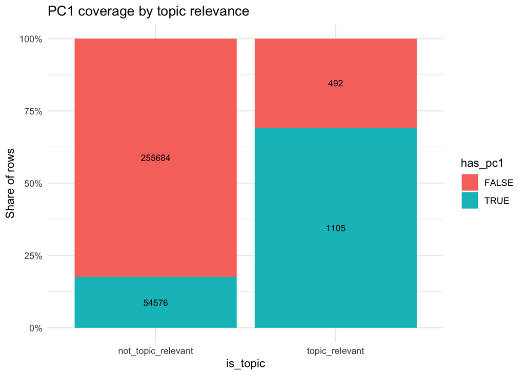

```r
save_diag(diag1, coverage_plot(diag1, "PC1 coverage by topic relevance", "is_topic"),
          "diag1_topic_pc1_crosstab")
```

The saved category crosstab is unrestricted; only the plot is limited to the largest categories plus `News`, forced in so the chart always shows where News sits relative to them.

```r
diag2 <- visits_experimental %>%
  filter(!is.na(category)) %>%
  coverage_table("category")

print(diag2 %>% arrange(desc(n_total_group)))
```

```
## # A tibble: 8 × 5
##   group      flag       n share_within_group n_total_group
##   <chr>      <lgl>  <int>              <dbl>         <int>
## 1 Other      FALSE 246799              0.889        277540
## 2 Other      TRUE   30741              0.111        277540
## 3 Search     FALSE   7088              0.324         21854
## 4 Search     TRUE   14766              0.676         21854
## 5 News       FALSE   1742              0.147         11834
## 6 News       TRUE   10092              0.853         11834
## 7 Government FALSE    547              0.870           629
## 8 Government TRUE      82              0.130           629
```

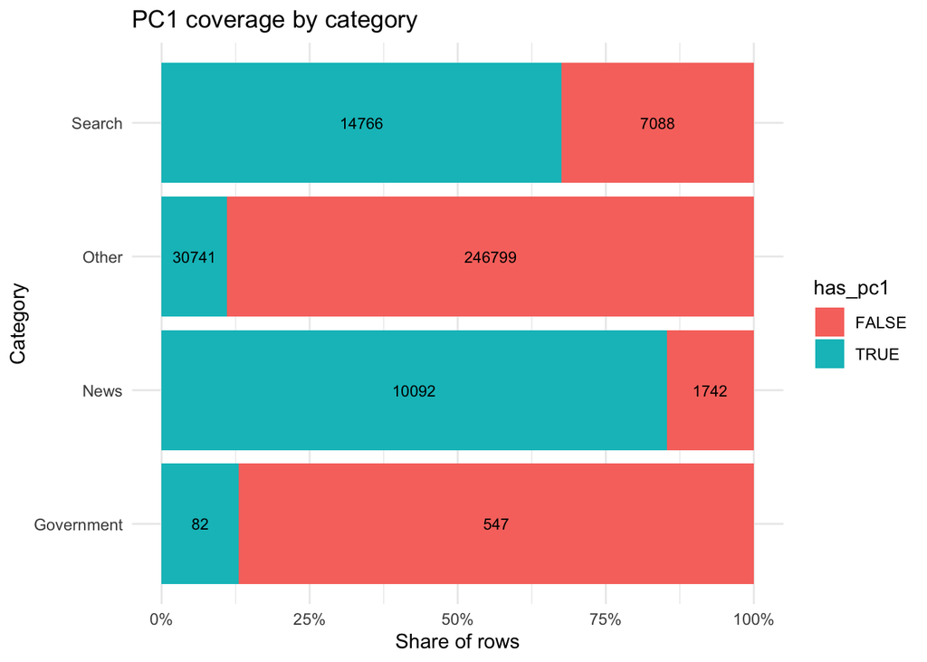

```r
top_categories <- diag2 %>%
  distinct(group, n_total_group) %>%
  slice_max(n_total_group, n = 4) %>%
  pull(group) %>%
  union("News")

save_diag(diag2, coverage_plot(diag2 %>% filter(group %in% top_categories),
                               "PC1 coverage by category", "Category", flip = TRUE),
          "diag2_category_pc1_crosstab", width = 8, height = 6)
```

Coverage inside the automated-News subset by wave. A low rate here directly caps how many participants can carry a quality exposure in that wave; the Wave 2 figure is the observed data limitation behind the small-sample caveat for the energy-transition topic, not a coding error.

```r
diag3 <- visits_experimental %>%
  filter(is_topic == 1, is_news_auto, !is.na(wave)) %>%
  coverage_table("wave")

print(diag3)
```

```
## # A tibble: 6 × 5
##   group flag      n share_within_group n_total_group
##   <int> <lgl> <int>              <dbl>         <int>
## 1     1 FALSE     1            0.00602           166
## 2     1 TRUE    165            0.994             166
## 3     2 FALSE     5            0.143              35
## 4     2 TRUE     30            0.857              35
## 5     3 FALSE     1            0.00870           115
## 6     3 TRUE    114            0.991             115
```

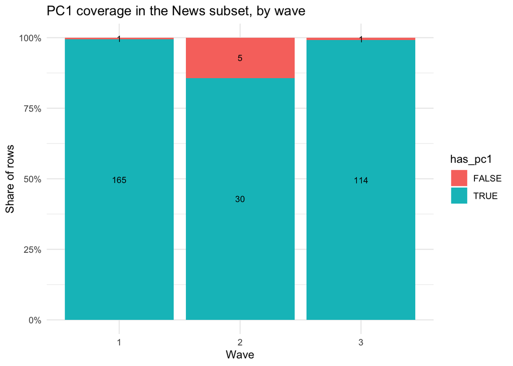

```r
save_diag(diag3, coverage_plot(diag3, "PC1 coverage in the News subset, by wave", "Wave"),
          "diag3_analysis_subset_pc1_by_wave", width = 6, height = 5)
```

# 9 Part 8: News Definitions and Category-Set Coverage

Cross-tabulation of the two news definitions on topic-relevant rows. Off-diagonal cells are the visits the manual coding adds and removes.

```r
diag4 <- visits_experimental %>%
  filter(is_topic == 1) %>%
  count(automated = is_news_auto, corrected = is_news_corrected) %>%
  pivot_wider(names_from = corrected, values_from = n,
              names_prefix = "corrected_", values_fill = 0L)

print(diag4)
```

```
## # A tibble: 2 × 3
##   automated corrected_FALSE corrected_TRUE
##   <lgl>               <int>          <int>
## 1 FALSE                1202             79
## 2 TRUE                    0            316
```

```r
write_csv(diag4, file.path(output_dir, "diag4_news_definition_agreement.csv"))
```

Participants per wave with a usable exposure, per news definition. The warning fires if the manually coded coverage falls below the externally classified coverage, which would indicate a failed domain join in Part 5.

```r
exposure_coverage <- function(df, flag_var, label) {
  df %>%
    filter(is_topic == 1, .data[[flag_var]], has_pc1, !is.na(wave)) %>%
    semi_join(analysis_pids, by = c("pid", "wave")) %>%
    distinct(pid, wave) %>%
    count(wave, name = "n_participants") %>%
    mutate(definition = label)
}

diag5 <- bind_rows(
  exposure_coverage(visits_experimental, "is_news_auto", "automated"),
  exposure_coverage(visits_experimental, "is_news_corrected", "corrected")
) %>%
  pivot_wider(names_from = definition, values_from = n_participants, values_fill = 0L)

print(diag5)
```

```
## # A tibble: 3 × 3
##    wave automated corrected
##   <int>     <int>     <int>
## 1     1        81        85
## 2     2        13        20
## 3     3        55        59
```

```r
write_csv(diag5, file.path(output_dir, "diag5_exposure_coverage_by_wave.csv"))

if (any(diag5$corrected < diag5$automated)) {
  warning("Corrected coverage falls below automated coverage in at least one wave. ",
          "Check the registered_domain / domain join in Part 5.")
}
```

The same count per category set, plus the category composition of the scored topic-relevant rows.

```r
ladder_coverage <- imap_dfr(CATEGORY_SETS, function(cats, set_name) {
  visits_experimental %>%
    filter(is_topic == 1, has_pc1, !is.na(wave), category %in% cats) %>%
    semi_join(analysis_pids, by = c("pid", "wave")) %>%
    distinct(pid, wave) %>%
    count(wave, name = "n_participants") %>%
    mutate(category_set = set_name)
}) %>%
  pivot_wider(names_from = wave, values_from = n_participants,
              names_prefix = "wave_", values_fill = 0L)

cat("Participants with a usable quality exposure, by category set and wave:\n")
```

```
## Participants with a usable quality exposure, by category set and wave:
```

```r
print(ladder_coverage)
```

```
## # A tibble: 3 × 4
##   category_set wave_1 wave_2 wave_3
##   <chr>         <int>  <int>  <int>
## 1 primary          89     24     85
## 2 news             81     13     55
## 3 all             136     93    108
```

```r
cat("\nCategory composition of scored topic-relevant rows, by wave:\n")
```

```
##
## Category composition of scored topic-relevant rows, by wave:
```

```r
visits_experimental %>%
  filter(is_topic == 1, has_pc1, !is.na(wave)) %>%
  semi_join(analysis_pids, by = c("pid", "wave")) %>%
  count(wave, category) %>%
  group_by(wave) %>%
  mutate(pct = round(100 * n / sum(n), 1)) %>%
  ungroup() %>%
  print(n = Inf)
```

```
## # A tibble: 10 × 4
##     wave category       n   pct
##    <int> <chr>      <int> <dbl>
##  1     1 News         165  35.8
##  2     1 Other         29   6.3
##  3     1 Search       267  57.9
##  4     2 News          28  11
##  5     2 Other         17   6.7
##  6     2 Search       209  82.3
##  7     3 Government    70  18.6
##  8     3 News         114  30.3
##  9     3 Other          3   0.8
## 10     3 Search       189  50.3
```

```r
write_csv(ladder_coverage, file.path(output_dir, "diag5b_ladder_coverage_by_wave.csv"))
```

Topic-relevant visits per category before and after the PC1 filter. The composition in the previous chunk is conditional on `has_pc1`; this one is not.

```r
diag5c <- visits_experimental %>%
  filter(is_topic == 1, !is.na(wave)) %>%
  semi_join(analysis_pids, by = c("pid", "wave")) %>%
  group_by(wave, category) %>%
  summarise(n_topic = n(),
            n_scored = sum(has_pc1),
            pct_scored = round(100 * mean(has_pc1), 1),
            .groups = "drop") %>%
  group_by(wave) %>%
  mutate(share_of_topic = round(100 * n_topic / sum(n_topic), 1)) %>%
  ungroup() %>%
  arrange(wave, desc(n_topic))

cat("Topic-relevant visits by category, before and after the PC1 filter:\n")
```

```
## Topic-relevant visits by category, before and after the PC1 filter:
```

```r
print(as.data.frame(diag5c))
```

```
##    wave   category n_topic n_scored pct_scored share_of_topic
## 1     1     Search     298      267       89.6           48.9
## 2     1       News     166      165       99.4           27.2
## 3     1      Other      94       29       30.9           15.4
## 4     1 Government      52        0        0.0            8.5
## 5     2     Search     236      209       88.6           43.1
## 6     2 Government     222        0        0.0           40.5
## 7     2      Other      57       17       29.8           10.4
## 8     2       News      33       28       84.8            6.0
## 9     3     Search     210      189       90.0           50.5
## 10    3       News     115      114       99.1           27.6
## 11    3 Government      77       70       90.9           18.5
## 12    3      Other      14        3       21.4            3.4
```

```r
write_csv(diag5c, file.path(output_dir, "diag5c_category_before_after_pc1.csv"))
```

Domains behind the government-category visits, with `in_lookup` indicating whether the domain occurs in the PC1 table at all. Separates absent ratings from a failed domain join.

```r
visits_experimental %>%
  filter(is_topic == 1, category == "Government", !is.na(wave)) %>%
  semi_join(analysis_pids, by = c("pid", "wave")) %>%
  count(wave, registered_domain, has_pc1, sort = TRUE) %>%
  group_by(wave) %>%
  slice_max(n, n = 8) %>%
  ungroup() %>%
  mutate(in_lookup = registered_domain %in% domain_pc1$domain) %>%
  as.data.frame() %>% print()
```

```
##    wave               registered_domain has_pc1  n in_lookup
## 1     1                    bundestag.de   FALSE 23     FALSE
## 2     1                  paritaet-bw.de   FALSE 19     FALSE
## 3     1               arbeitsagentur.de   FALSE  5     FALSE
## 4     1                       bmfsfj.de   FALSE  5     FALSE
## 5     2         erneuerbare-energien.de   FALSE 98     FALSE
## 6     2                         bmwk.de   FALSE 42     FALSE
## 7     2               energiewechsel.de   FALSE 18     FALSE
## 8     2              bundesregierung.de   FALSE 17     FALSE
## 9     2              umweltbundesamt.de   FALSE 14     FALSE
## 10    2                         bund.de   FALSE  7     FALSE
## 11    2                    bundestag.de   FALSE  7     FALSE
## 12    2    klimaschutz-niedersachsen.de   FALSE  7     FALSE
## 13    2          verbraucherzentrale.de   FALSE  7     FALSE
## 14    3 bundesgesundheitsministerium.de    TRUE 70      TRUE
## 15    3                    bundestag.de   FALSE  4     FALSE
## 16    3              bundesregierung.de   FALSE  2     FALSE
## 17    3     bundesdrogenbeauftragter.de   FALSE  1     FALSE
```

# 10 Part 9: Topic Uptake and Effort

Aggregated to `pid` x `wave` over all in-window rows, before sample restriction. Uptake is the union of topic-relevant URL and search visits; the two components are kept separately for the verification in Part 10.

| Measure | Definition | Role |
| --- | --- | --- |
| `exp_topic_uptake_yn` | At least one topic-relevant visit | Uptake (Eq. 3.1) |
| `exp_topic_uptake_n` | Count of topic-relevant visits | Effort, primary (Eq. 3.2) |
| `n_topic_domains` | Distinct topic-relevant domains | Effort, supplementary |
| `topic_duration` | Seconds on topic-relevant visits | Effort, supplementary |
| `exp_topic_uptake_dw` | Share of browsing time on topic-relevant visits | Duration-weighted uptake |

`exp_topic_uptake_dw` is the duration-weighted mean of the binary `is_topic` indicator. Its denominator is all in-window visits of the participant-wave; the quality measures in Part 12 condition on scored visits instead.

```r
topic_uptake <- visits_experimental %>%
  filter(!is.na(wave)) %>%
  mutate(is_topic_bin = as.integer(is_topic == 1)) %>%
  group_by(pid, wave) %>%
  summarise(
    n_visits_total         = n(),
    exp_topic_uptake_n     = sum(is_topic_bin, na.rm = TRUE),
    exp_topic_uptake_yn    = as.integer(any(is_topic_bin == 1, na.rm = TRUE)),
    n_topic_search         = sum(is_topic_bin == 1 & category == "Search", na.rm = TRUE),
    n_topic_url            = sum(is_topic_bin == 1 &
                                   (category != "Search" | is.na(category)), na.rm = TRUE),
    n_topic_domains        = n_distinct(registered_domain[is_topic_bin == 1 &
                                                            !is.na(registered_domain)]),
    total_duration         = sum(duration, na.rm = TRUE),
    topic_duration         = sum(duration[is_topic_bin == 1], na.rm = TRUE),
    exp_topic_uptake_dw    = weighted_mean_na(is_topic_bin, duration),
    exp_topic_uptake_logdw = weighted_mean_log_na(is_topic_bin, duration),
    .groups = "drop"
  )

# The two components must exhaust the union, without double counting.
stopifnot(all(topic_uptake$n_topic_url + topic_uptake$n_topic_search ==
                topic_uptake$exp_topic_uptake_n))
# The binary flag must agree with a positive count.
stopifnot(all((topic_uptake$exp_topic_uptake_n > 0) ==
                (topic_uptake$exp_topic_uptake_yn == 1)))

cat("Participant-wave cells before restriction:", nrow(topic_uptake), "\n")
```

```
## Participant-wave cells before restriction: 1840
```

```r
cat("\nRaw vs. log-duration-weighted uptake share, by wave:\n")
```

```
##
## Raw vs. log-duration-weighted uptake share, by wave:
```

```r
topic_uptake %>%
  filter(!is.na(exp_topic_uptake_dw), !is.na(exp_topic_uptake_logdw)) %>%
  group_by(wave) %>%
  summarise(n = n(),
            r = round(cor(exp_topic_uptake_dw, exp_topic_uptake_logdw), 3),
            mean_abs_diff = round(mean(abs(exp_topic_uptake_dw - exp_topic_uptake_logdw)), 5),
            .groups = "drop") %>%
  print()
```

```
## # A tibble: 3 × 4
##    wave     n     r mean_abs_diff
##   <int> <int> <dbl>         <dbl>
## 1     1   606 0.809       0.00591
## 2     2   626 0.864       0.00435
## 3     3   608 0.856       0.00437
```

# 11 Part 10: Restricting to the Analysis Samples

Reconciliation runs before restriction, while the surplus cells still exist. Surplus cells are participants tracked during a wave they did not take part in; the second output reports how many other waves they appear in.

```r
recon <- topic_uptake %>%
  full_join(analysis_pids %>% mutate(in_analysis = TRUE), by = c("pid", "wave")) %>%
  mutate(in_uptake   = !is.na(exp_topic_uptake_yn),
         in_analysis = coalesce(in_analysis, FALSE))

cat("Uptake cells vs. wave analysis samples:\n")
```

```
## Uptake cells vs. wave analysis samples:
```

```r
recon %>% count(wave, in_uptake, in_analysis) %>% print()
```

```
## # A tibble: 9 × 4
##    wave in_uptake in_analysis     n
##   <int> <lgl>     <lgl>       <int>
## 1     1 FALSE     TRUE           17
## 2     1 TRUE      FALSE          37
## 3     1 TRUE      TRUE          569
## 4     2 FALSE     TRUE            5
## 5     2 TRUE      FALSE          33
## 6     2 TRUE      TRUE          593
## 7     3 FALSE     TRUE            6
## 8     3 TRUE      FALSE           8
## 9     3 TRUE      TRUE          600
```

```r
cat("\nSurplus cells: number of other waves these participants appear in\n")
```

```
##
## Surplus cells: number of other waves these participants appear in
```

```r
recon %>%
  filter(in_uptake, !in_analysis) %>%
  distinct(pid) %>%
  inner_join(analysis_pids, by = "pid") %>%
  count(pid) %>%
  count(n, name = "n_participants") %>%
  rename(n_other_waves = n) %>%
  print()
```

```
## # A tibble: 2 × 2
##   n_other_waves n_participants
##           <int>          <int>
## 1             1             23
## 2             2             45
```

The window filter can leave a participant-wave with no tracked rows, and therefore with no uptake cell. Those cells are restored through a left join and coded as zero uptake.

```r
UPTAKE_ZERO <- c(n_visits_total = 0, exp_topic_uptake_n = 0, exp_topic_uptake_yn = 0,
                 n_topic_search = 0, n_topic_url = 0, n_topic_domains = 0,
                 total_duration = 0, topic_duration = 0)

topic_uptake <- analysis_pids %>%
  left_join(topic_uptake, by = c("pid", "wave")) %>%
  mutate(across(all_of(names(UPTAKE_ZERO)), ~ coalesce(.x, 0)),
         across(c(exp_topic_uptake_n, exp_topic_uptake_yn, n_topic_search,
                  n_topic_url, n_topic_domains, n_visits_total), as.integer))

n_empty <- sum(topic_uptake$n_visits_total == 0)
cat("Participant-waves with no tracked rows inside the window:", n_empty, "\n")
```

```
## Participant-waves with no tracked rows inside the window: 28
```

```r
stopifnot(nrow(topic_uptake) == nrow(analysis_pids))
stopifnot(!any(duplicated(topic_uptake[c("pid", "wave")])))

cat("Uptake after restriction:\n")
```

```
## Uptake after restriction:
```

```r
topic_uptake %>%
  group_by(wave) %>%
  summarise(n_cells        = n(),
            n_uptake_yes   = sum(exp_topic_uptake_yn),
            pct_uptake_yes = round(100 * mean(exp_topic_uptake_yn), 1),
            .groups = "drop") %>%
  print()
```

```
## # A tibble: 3 × 4
##    wave n_cells n_uptake_yes pct_uptake_yes
##   <int>   <int>        <int>          <dbl>
## 1     1     586          147           25.1
## 2     2     598          122           20.4
## 3     3     606          109           18
```

```r
write_csv(topic_uptake, file.path(output_dir, "experimental_topic_uptake_by_wave.csv"))
saveRDS(topic_uptake, file.path(output_dir, "experimental_topic_uptake_by_wave.Rds"))
```

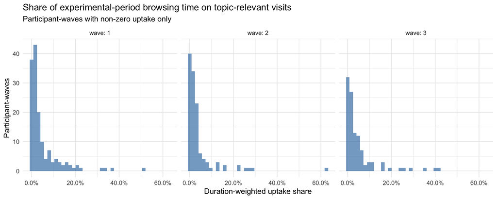

```r
p_uptake <- topic_uptake %>%
  filter(exp_topic_uptake_dw > 0) %>%
  ggplot(aes(x = exp_topic_uptake_dw)) +
  geom_histogram(bins = 40, fill = "steelblue", alpha = 0.7) +
  facet_wrap(~ wave, nrow = 1, labeller = label_both) +
  scale_x_continuous(labels = scales::percent_format(accuracy = 0.1)) +
  labs(title = "Share of experimental-period browsing time on topic-relevant visits",
       subtitle = "Participant-waves with non-zero uptake only",
       x = "Duration-weighted uptake share", y = "Participant-waves") +
  theme_minimal()

print(p_uptake)
```

```r
ggsave(file.path(output_dir, "uptake_duration_share_by_wave.png"), p_uptake, width = 10, height = 4)
```

## 11.1 Verification against `url_int_visits_yn`

`url_int_visits_yn` excludes search-engine pages; the reconstruction is the union of URL and search visits. The outputs quantify the disagreement, split it by component, and report it by arm.

```r
agreement <- topic_uptake %>%
  inner_join(supplied_uptake, by = c("pid", "wave")) %>%
  mutate(
    supplied      = as.integer(url_int_visits_yn),
    reconstructed = as.integer(exp_topic_uptake_yn),
    # The variant that should match the documented construction of the
    # supplied variable: same union, search visits removed.
    reconstructed_nosearch = as.integer(n_topic_url > 0),
    status = case_when(
      supplied == reconstructed          ~ "agree",
      supplied == 0 & reconstructed == 1 ~ "reconstructed only",
      supplied == 1 & reconstructed == 0 ~ "supplied only"
    )
  )

stopifnot(nrow(agreement) == nrow(topic_uptake))

cat("Agreement, reconstructed (incl. search) vs. url_int_visits_yn:\n")
```

```
## Agreement, reconstructed (incl. search) vs. url_int_visits_yn:
```

```r
agreement %>%
  group_by(wave) %>%
  summarise(n = n(),
            pct_agree    = round(100 * mean(status == "agree"), 1),
            n_recon_only = sum(status == "reconstructed only"),
            n_suppl_only = sum(status == "supplied only"),
            .groups = "drop") %>%
  print()
```

```
## # A tibble: 3 × 5
##    wave     n pct_agree n_recon_only n_suppl_only
##   <int> <int>     <dbl>        <int>        <int>
## 1     1   586      96.9           18            0
## 2     2   598      96.2           23            0
## 3     3   606      96.9           19            0
```

```r
# Agreement with and without search visits, to attribute the disagreement.
cat("\nAgreement with and without search visits in the reconstruction:\n")
```

```
##
## Agreement with and without search visits in the reconstruction:
```

```r
agreement %>%
  group_by(wave) %>%
  summarise(n = n(),
            pct_agree_with_search = round(100 * mean(supplied == reconstructed), 1),
            pct_agree_no_search   = round(100 * mean(supplied == reconstructed_nosearch), 1),
            .groups = "drop") %>%
  print()
```

```
## # A tibble: 3 × 4
##    wave     n pct_agree_with_search pct_agree_no_search
##   <int> <int>                 <dbl>               <dbl>
## 1     1   586                  96.9                 100
## 2     2   598                  96.2                 100
## 3     3   606                  96.9                 100
```

```r
cat("\nComposition of 'reconstructed only' cells:\n")
```

```
##
## Composition of 'reconstructed only' cells:
```

```r
agreement %>%
  filter(status == "reconstructed only") %>%
  mutate(component = case_when(
    n_topic_url == 0 & n_topic_search >  0 ~ "search visits only",
    n_topic_url >  0 & n_topic_search == 0 ~ "URL visits only",
    TRUE                                   ~ "both"
  )) %>%
  count(wave, component) %>%
  print(n = Inf)
```

```
## # A tibble: 3 × 3
##    wave component              n
##   <int> <chr>              <int>
## 1     1 search visits only    18
## 2     2 search visits only    23
## 3     3 search visits only    19
```

```r
# Cells where the supplied variable finds uptake and the reconstruction does
# not. n_zero_tracked_rows separates tracking gaps from classification gaps.
cat("\nComposition of 'supplied only' cells:\n")
```

```
##
## Composition of 'supplied only' cells:
```

```r
agreement %>%
  filter(status == "supplied only") %>%
  summarise(n = n(),
            median_visits_total = median(n_visits_total),
            n_zero_tracked_rows = sum(n_visits_total == 0)) %>%
  print()
```

```
## # A tibble: 1 × 3
##       n median_visits_total n_zero_tracked_rows
##   <int>               <int>               <int>
## 1     0                  NA                   0
```

```r
# Agreement and both uptake rates by arm.
cat("\nAgreement by wave and condition:\n")
```

```
##
## Agreement by wave and condition:
```

```r
agreement %>%
  group_by(wave, intervention) %>%
  summarise(n = n(),
            pct_agree          = round(100 * mean(status == "agree"), 1),
            rate_supplied      = round(100 * mean(supplied), 1),
            rate_reconstructed = round(100 * mean(reconstructed), 1),
            .groups = "drop") %>%
  print(n = Inf)
```

```
## # A tibble: 9 × 6
##    wave intervention     n pct_agree rate_supplied rate_reconstructed
##   <int> <chr>        <int>     <dbl>         <dbl>              <dbl>
## 1     1 control        193      97.9           3.6                5.7
## 2     1 monetary       217      95.9          38.2               42.4
## 3     1 verbal         176      97.2          22.2               25
## 4     2 control        194      96.9           4.1                7.2
## 5     2 monetary       190      95.3          28.9               33.7
## 6     2 verbal         214      96.3          16.8               20.6
## 7     3 control        207      98.1           2.9                4.8
## 8     3 monetary       192      95.8          25                 29.2
## 9     3 verbal         207      96.6          17.4               20.8
```

```r
write_csv(
  agreement %>% select(pid, wave, intervention, supplied, reconstructed,
                       reconstructed_nosearch, n_topic_url, n_topic_search, status),
  file.path(output_dir, "uptake_agreement_vs_url_int_visits_yn.csv"))
```

Participant-waves without a tracked row inside the window, by arm.

```r
armcheck <- topic_uptake %>%
  left_join(supplied_uptake %>% select(pid, wave, intervention),
            by = c("pid", "wave")) %>%
  group_by(wave, intervention) %>%
  summarise(n = n(),
            n_empty = sum(n_visits_total == 0),
            pct = round(100 * mean(n_visits_total == 0), 1),
            .groups = "drop")

cat("Participant-waves with no tracked rows inside the window, by arm:\n")
```

```
## Participant-waves with no tracked rows inside the window, by arm:
```

```r
print(as.data.frame(armcheck))
```

```
##   wave intervention   n n_empty pct
## 1    1      control 193       4 2.1
## 2    1     monetary 217       9 4.1
## 3    1       verbal 176       4 2.3
## 4    2      control 194       1 0.5
## 5    2     monetary 190       2 1.1
## 6    2       verbal 214       2 0.9
## 7    3      control 207       3 1.4
## 8    3     monetary 192       1 0.5
## 9    3       verbal 207       2 1.0
```

```r
write_csv(armcheck, file.path(output_dir, "diag0d_empty_cells_by_arm.csv"))
```

# 12 Part 11: Duration Distribution

Duration of the scored topic-relevant visits that enter the primary quality measure, checked before that measure is built. Reported with thresholds at 10, 30 and 60 minutes and with the share of a participant-wave’s topic time carried by its longest visit.

```r
dur_check <- visits_experimental %>%
  filter(is_topic == 1, has_pc1, !is.na(wave), category %in% CATEGORY_SETS$primary) %>%
  semi_join(analysis_pids, by = c("pid", "wave"))

cat("Duration of scored topic-relevant visits (seconds):\n")
```

```
## Duration of scored topic-relevant visits (seconds):
```

```r
dur_check %>%
  summarise(n = n(),
            min = min(duration), p25 = quantile(duration, .25),
            median = median(duration), p75 = quantile(duration, .75),
            p95 = quantile(duration, .95), p99 = quantile(duration, .99),
            max = max(duration), n_zero = sum(duration == 0)) %>%
  as.data.frame() %>% print()
```

```
##     n min p25 median    p75   p95    p99  max n_zero
## 1 426   1  20     72 175.75 428.5 826.25 1193      0
```

```r
cat("\nVisits above plausible reading thresholds:\n")
```

```
##
## Visits above plausible reading thresholds:
```

```r
dur_check %>%
  summarise(n = n(),
            over_10min = sum(duration > 600),
            over_30min = sum(duration > 1800),
            over_1h    = sum(duration > 3600),
            pct_over_30min = round(100 * mean(duration > 1800), 2),
            share_time_over_30min =
              round(100 * sum(duration[duration > 1800]) / sum(duration), 1)) %>%
  as.data.frame() %>% print()
```

```
##     n over_10min over_30min over_1h pct_over_30min share_time_over_30min
## 1 426         10          0       0              0                     0
```

```r
# Restricted to participant-waves with at least two scored visits; the
# single-visit cases would otherwise enter with a top share of 100 per cent
# and are counted separately in Part 12.
cat("\nShare of a participant-wave's topic time in its longest visit:\n")
```

```
##
## Share of a participant-wave's topic time in its longest visit:
```

```r
dur_check %>%
  group_by(pid, wave) %>%
  filter(n() >= 2) %>%
  summarise(top_share = max(duration) / sum(duration), .groups = "drop") %>%
  group_by(wave) %>%
  summarise(n_participants = n(),
            median_top_share = round(median(top_share), 3),
            pct_over_50 = round(100 * mean(top_share > .5), 1),
            pct_over_80 = round(100 * mean(top_share > .8), 1),
            .groups = "drop") %>%
  as.data.frame() %>% print()
```

```
##   wave n_participants median_top_share pct_over_50 pct_over_80
## 1    1             53            0.690        79.2        30.2
## 2    2             13            0.780        84.6        46.2
## 3    3             41            0.715        82.9        29.3
```

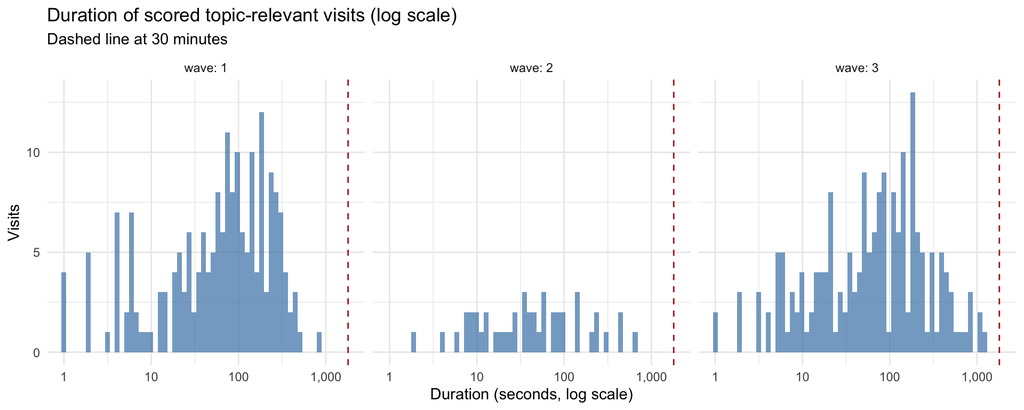

```r
p_dur <- dur_check %>%
  filter(duration > 0) %>%
  ggplot(aes(x = duration)) +
  geom_histogram(bins = 60, fill = "steelblue", alpha = .7) +
  geom_vline(xintercept = 1800, linetype = "dashed", colour = "firebrick") +
  scale_x_log10(labels = scales::comma) +
  facet_wrap(~ wave, nrow = 1, labeller = label_both) +
  labs(title = "Duration of scored topic-relevant visits (log scale)",
       subtitle = "Dashed line at 30 minutes",
       x = "Duration (seconds, log scale)", y = "Visits") +
  theme_minimal()

print(p_dur)
```

```r
ggsave(file.path(output_dir, "duration_distribution_by_wave.png"), p_dur, width = 10, height = 4)
```

# 13 Part 12: Quality Exposure

At `pid` x `wave`: three category sets (Part 1) x three weightings. The primary measure is `exp_q_dur`.

| Variable | Weighting | Role |
| --- | --- | --- |
| `exp_q_dur` | duration | Primary |
| `exp_q_unw` | equal per visit | Sensitivity |
| `exp_q_log` | log1p(duration) | Sensitivity |

Suffix `_news` is the News-only set, `_all` includes Search, no suffix is the primary set. A participant-wave without a scored visit in a given set receives `NA`, never 0.

```r
build_quality <- function(cats, set_name) {
  suffix <- SUFFIX_FOR[[set_name]]
  visits_experimental %>%
    filter(is_topic == 1, has_pc1, !is.na(wave), category %in% cats) %>%
    semi_join(analysis_pids, by = c("pid", "wave")) %>%
    group_by(pid, wave) %>%
    summarise(
      n_scored  = n(),
      n_domains = n_distinct(registered_domain),
      dur       = weighted_mean_na(pc1, duration),
      unw       = mean(pc1, na.rm = TRUE),
      log       = weighted_mean_log_na(pc1, duration),
      .groups   = "drop"
    ) %>%
    rename_with(~ paste0("exp_q_", .x, suffix), c(dur, unw, log)) %>%
    rename_with(~ paste0(.x, suffix), c(n_scored, n_domains))
}

# Left join onto the analysis sample so participants without a scored visit
# appear as NA rather than being dropped.
quality_exposure <- analysis_pids %>%
  left_join(
    Reduce(function(a, b) full_join(a, b, by = c("pid", "wave")),
           imap(CATEGORY_SETS, build_quality)),
    by = c("pid", "wave"))

stopifnot(nrow(quality_exposure) == nrow(analysis_pids))

cat("Participants with a usable quality score, by set and wave:\n")
```

```
## Participants with a usable quality score, by set and wave:
```

```r
quality_exposure %>%
  group_by(wave) %>%
  summarise(n_cells = n(),
            primary     = sum(!is.na(exp_q_dur)),
            news_only   = sum(!is.na(exp_q_dur_news)),
            incl_search = sum(!is.na(exp_q_dur_all)),
            .groups = "drop") %>%
  as.data.frame() %>% print()
```

```
##   wave n_cells primary news_only incl_search
## 1    1     586      89        81         136
## 2    2     598      24        13          93
## 3    3     606      85        55         108
```

```r
cat("\nDistribution of the primary measure, by wave:\n")
```

```
##
## Distribution of the primary measure, by wave:
```

```r
quality_exposure %>%
  filter(!is.na(exp_q_dur)) %>%
  group_by(wave) %>%
  summarise(n = n(),
            median = round(median(exp_q_dur), 3),
            mean   = round(mean(exp_q_dur), 3),
            sd     = round(sd(exp_q_dur), 3),
            min    = round(min(exp_q_dur), 3),
            max    = round(max(exp_q_dur), 3),
            .groups = "drop") %>%
  as.data.frame() %>% print()
```

```
##   wave  n median  mean    sd   min   max
## 1    1 89  0.732 0.759 0.137 0.479 0.932
## 2    2 24  0.766 0.745 0.108 0.375 0.834
## 3    3 85  0.683 0.714 0.109 0.512 0.932
```

Three groups: no topic-relevant activity, activity without a scored domain, and at least one scored domain.

```r
triage <- topic_uptake %>%
  select(pid, wave, exp_topic_uptake_yn) %>%
  left_join(quality_exposure %>% select(pid, wave, exp_q_dur), by = c("pid", "wave")) %>%
  mutate(group = case_when(
    exp_topic_uptake_yn == 0 ~ "1: no topic-relevant activity",
    is.na(exp_q_dur)         ~ "2: activity, no scored domain",
    TRUE                     ~ "3: at least one scored domain"
  ))

triage %>%
  count(wave, group) %>%
  group_by(wave) %>%
  mutate(pct = round(100 * n / sum(n), 1)) %>%
  ungroup() %>%
  as.data.frame() %>% print()
```

```
##   wave                         group   n  pct
## 1    1 1: no topic-relevant activity 439 74.9
## 2    1 2: activity, no scored domain  58  9.9
## 3    1 3: at least one scored domain  89 15.2
## 4    2 1: no topic-relevant activity 476 79.6
## 5    2 2: activity, no scored domain  98 16.4
## 6    2 3: at least one scored domain  24  4.0
## 7    3 1: no topic-relevant activity 497 82.0
## 8    3 2: activity, no scored domain  24  4.0
## 9    3 3: at least one scored domain  85 14.0
```

```r
write_csv(triage, file.path(output_dir, "quality_coverage_triage.csv"))
```

Correlation between the three weightings, and the number of scored visits and distinct domains behind each primary score.

```r
cat("Agreement between weightings, primary category set:\n")
```

```
## Agreement between weightings, primary category set:
```

```r
quality_exposure %>%
  filter(!is.na(exp_q_dur)) %>%
  group_by(wave) %>%
  summarise(n = n(),
            r_dur_unw = round(cor(exp_q_dur, exp_q_unw, use = "complete.obs"), 3),
            r_dur_log = round(cor(exp_q_dur, exp_q_log, use = "complete.obs"), 3),
            .groups = "drop") %>%
  as.data.frame() %>% print()
```

```
##   wave  n r_dur_unw r_dur_log
## 1    1 89     0.979     0.989
## 2    2 24     0.987     0.994
## 3    3 85     0.984     0.992
```

```r
cat("\nScored visits behind each primary score:\n")
```

```
##
## Scored visits behind each primary score:
```

```r
quality_exposure %>%
  filter(!is.na(exp_q_dur)) %>%
  group_by(wave) %>%
  summarise(n = n(),
            median_visits  = median(n_scored),
            pct_single     = round(100 * mean(n_scored == 1), 1),
            pct_two_orless = round(100 * mean(n_scored <= 2), 1),
            median_domains = median(n_domains),
            .groups = "drop") %>%
  as.data.frame() %>% print()
```

```
##   wave  n median_visits pct_single pct_two_orless median_domains
## 1    1 89             2       40.4           71.9              1
## 2    2 24             2       45.8           87.5              1
## 3    3 85             1       51.8           78.8              1
```

Coverage and dispersion of the primary measure with and without the single domain that carries most of the scored government visits, plus the most frequent scored domains per wave.

```r
DROP_DOMAIN <- "bundesgesundheitsministerium.de"

q_without <- visits_experimental %>%
  filter(is_topic == 1, has_pc1, !is.na(wave),
         category %in% CATEGORY_SETS$primary,
         registered_domain != DROP_DOMAIN) %>%
  semi_join(analysis_pids, by = c("pid", "wave")) %>%
  group_by(pid, wave) %>%
  summarise(q_excl = weighted_mean_na(pc1, duration), .groups = "drop")

quality_exposure %>%
  select(pid, wave, q_incl = exp_q_dur) %>%
  full_join(q_without, by = c("pid", "wave")) %>%
  group_by(wave) %>%
  summarise(n_incl   = sum(!is.na(q_incl)),
            n_excl   = sum(!is.na(q_excl)),
            sd_incl  = round(sd(q_incl, na.rm = TRUE), 4),
            sd_excl  = round(sd(q_excl, na.rm = TRUE), 4),
            mean_incl = round(mean(q_incl, na.rm = TRUE), 3),
            mean_excl = round(mean(q_excl, na.rm = TRUE), 3),
            r        = round(cor(q_incl, q_excl, use = "complete.obs"), 3),
            .groups  = "drop") %>%
  as.data.frame() %>% print()
```

```
##   wave n_incl n_excl sd_incl sd_excl mean_incl mean_excl     r
## 1    1     89     89  0.1372  0.1372     0.759     0.759 1.000
## 2    2     24     24  0.1085  0.1085     0.745     0.745 1.000
## 3    3     85     55  0.1091  0.1385     0.714     0.733 0.972
```

```r
# Most frequent scored domains per wave, with their share of scored rows.
visits_experimental %>%
  filter(is_topic == 1, has_pc1, !is.na(wave),
         category %in% CATEGORY_SETS$primary) %>%
  semi_join(analysis_pids, by = c("pid", "wave")) %>%
  count(wave, registered_domain, sort = TRUE) %>%
  group_by(wave) %>%
  mutate(share = round(100 * n / sum(n), 1)) %>%
  slice_max(n, n = 5) %>%
  ungroup() %>%
  as.data.frame() %>% print()
```

```
##    wave               registered_domain  n share
## 1     1                          zdf.de 63  32.5
## 2     1        deutschlandfunkkultur.de 38  19.6
## 3     1                   wikipedia.org 27  13.9
## 4     1                   tagesschau.de 17   8.8
## 5     1                       merkur.de  8   4.1
## 6     2                   wikipedia.org 14  31.1
## 7     2                         msn.com  7  15.6
## 8     2                          web.de  4   8.9
## 9     2                           br.de  3   6.7
## 10    2                        focus.de  2   4.4
## 11    2                         gmx.net  2   4.4
## 12    2                          mdr.de  2   4.4
## 13    2                     youtube.com  2   4.4
## 14    3 bundesgesundheitsministerium.de 70  37.4
## 15    3                      spiegel.de 25  13.4
## 16    3                          zdf.de 18   9.6
## 17    3                   tagesschau.de 14   7.5
## 18    3                          mdr.de 12   6.4
```

# 14 Part 13: Saving

```r
saveRDS(quality_exposure, file.path(output_dir, "experimental_quality_by_wave.Rds"))
#write_csv(quality_exposure, file.path(output_dir, "experimental_quality_by_wave.csv"))

saveRDS(visits_experimental, file.path(output_dir, "visits_experimental_period_pc1.Rds"))
#write_csv(visits_experimental, file.path(output_dir, "visits_experimental_period_pc1.csv"))

cat("Saved:", nrow(visits_experimental), "visits |",
    nrow(topic_uptake), "participant-waves (uptake) |",
    nrow(quality_exposure), "participant-waves (quality)\n")
```

```
## Saved: 311857 visits | 1790 participant-waves (uptake) | 1790 participant-waves (quality)
```